# TDA, Human Activity Recognition, and R

December 1, 2014

## Question

Can topological data analysis (TDA) accurately identify different human movements based on data collected from cell phones?

### Motivation

- Practical application
- Theoretically, TDA should be a powerful clustering tool
- Benchmark TDA against tried and true clustering methods
- Determine TDA's usefulness on larger data sets
- Test R's capacity to perform TDA

## Data Set

The data in this analysis come from the University of California Irvine (UCI) Machine Learning Repository. The data originally come from Davide Anguita, Alessandro Ghio, and Luca Oneto (2012).

- 30 subjects
- 6 activities (walking, walking up stairs, walking down stairs, sitting, standing, and lying)
- 561 features from each 2.56 second region
- Training (70%) and test set (30%)

The researchers' support vector machine was very effective in clustering and classifying the data. Their overall accuracy in the test set was about 89%.

## TDA in R

### What is R?

R is an open-source language and environment for statistical computing and graphics with an active community of developers and users. According to the TIOBE index, R is ranked 12th out of all languages (higher than MATLAB, SAS, SPSS, and STATA).

### TDA option(s)

Currently, there are really only two packages in R for TDA: 'TDA' by Fasy, Kim, Lecci, and Maria and 'pHom' by Tausz.

## pHom

The package 'pHom' has the unfortunate habit of causing fatal errors in the R session whenever it tries to compute persistent homology on new data sets (not the example data sets given in the package). Due to this, I was unable to do any sort of testing with this package.

## TDA

The TDA package luckily computes persistent homology correctly. However, it is also slow. The following is a benchmark consisting of 600 points in 6 dimensional ambient space. (This data set is seen again later)

```r
library(TDA,quietly=T)
start = proc.time()
rpd = ripsDiag(testSet,1,15)
proc.time()-start
```

```
##    user  system elapsed
##  50.841   1.298  53.044
```

This package does provide good functionality with the persistence diagrams and statistical tools that can be used on the output of the persistent homology algorithms.

## TDA (con't)

However, what the TDA package lacks is a fast algorithm for calculating persistent homology. For comparison, I ran the same analysis in MATLAB, executing the following code:

```
tic;
rca1pc(testSet,15);
toc
```

This informed me that the function took 23.411981 seconds to complete; less than half of R's TDA implementation.

Considering this was a set of only 600 points in 6 dimensional space, it should be clear that R's TDA packages are a poor choice for any substantially sized data set, but are workable for small data sets.

## Clustering with TDA

*Clustering* is the task of grouping a set of objects in such a way that objects of the same group are more similar to each other than those in other groups.

In our data set, we are attempting to determine the effectiveness of TDA for clustering our data. Therefore, we must get an idea of what to expect from TDA when we have different data situations. In order to do this, simulation using synthetic data is very helpful. In this simulation I used 600 points sitting in 6 dimensional space.

## Simulation

```r
set.seed(1011)
center1 = c(1:6); center2 = c(2:6,1); center3 = c(3:6,1:2)
center4 = c(4:6,1:3); center5 = c(5:6,1:4); center6 = c(6,1:5)
sd = .63
testSet = as.data.frame(matrix(nrow = 600,ncol=6))
centers = c(center1,center2,center3,center4,center5,center6)
for(k in 1:6){
    for(i in 1:100){
        for(j in 1:6){
            loc = rnorm(1,centers[(k-1)*6 + j],sd)
            testSet[(k-1)*100+i,j] = loc
        }
    }
}
testSet$grp = c(rep(1,100),rep(2,100),rep(3,100),
                rep(4,100),rep(5,100),rep(6,100))
```

*Note, this is the same data set as used in the benchmark*

## Clustering with TDA

Our data should be fairly well separated in our ambient space. There will be some overlap between groups in any given 'feature'. In any feature, the histogram should look very similar to this (though the groups will permute through).

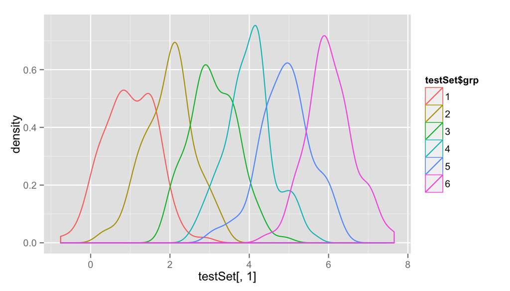

## Clustering with TDA

An easy way to visualize that these separate out very well is to use principal components analysis (PCA) and plot the first two principal components against one another.

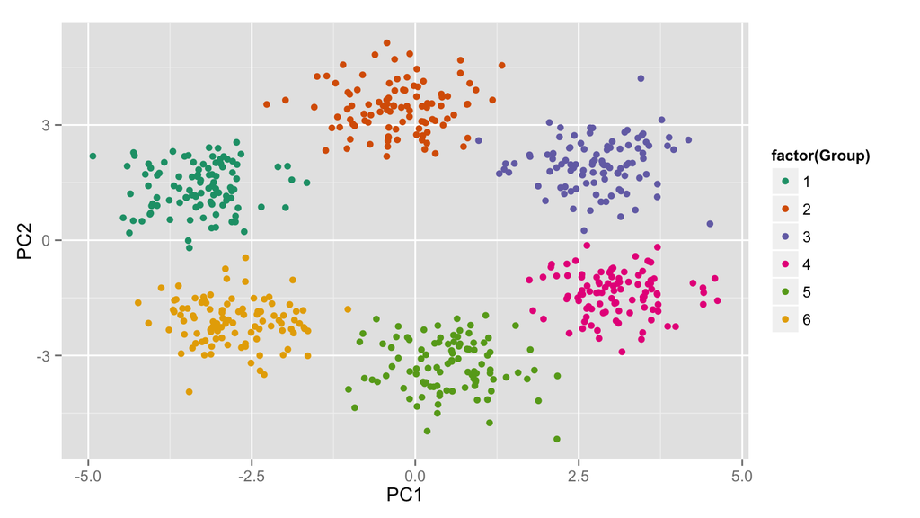

## Clustering with TDA

Now that we can see there is good separation between groups, what does the TDA output tell us? Note that since we are using a point cloud, all connected components are born at 0 and die when they connect to a neighboring connected set. This makes for a relatively uninteresting persistence diagram.

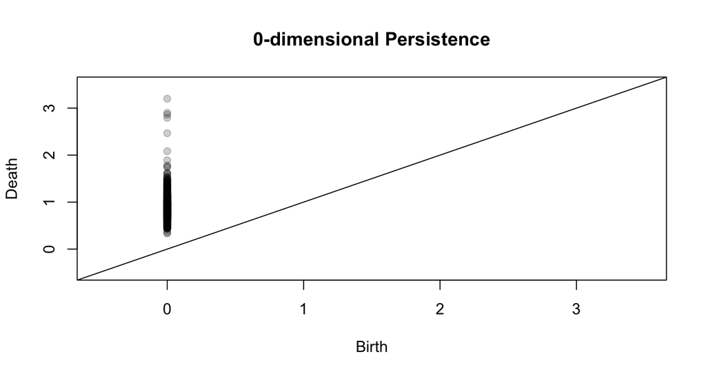

## Clustering with TDA

We can see that there does appear to be a break between the noise from points within groups connecting (earlier deaths) and the groups connecting to each other (later deaths). However, since this is really one dimensional data (all births occur at time 0), it makes more sense to visualize with a (cropped) histogram.

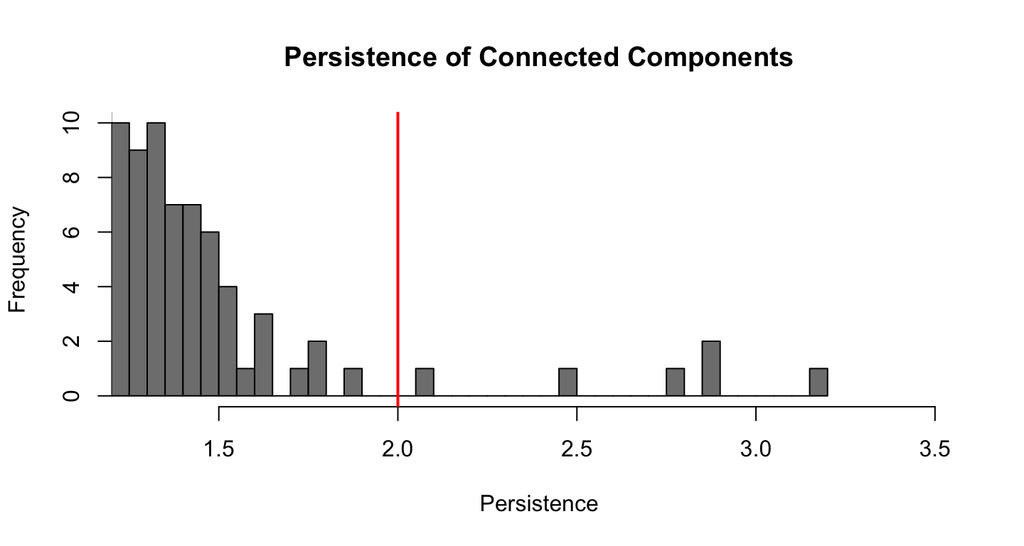

## Clustering with TDA

Take-aways from the simulation:

- The persistence diagram may not be extremely clear
- Effective in identifying rough number of groups
- Seeing a steep decline in the histogram followed by bins with single observations spaced apart may indicate the presence of clustering

## Clustering the Data

My initial approach was to run the persistent homology algorithm on the entire training data set (7352 observations, 561 features). This would be the ideal way of identifying homological features. Below are my attempts at computing persistence on the entire data set

- Attempt 1: Full data set, no modifications: Ran out of Java Heap Space in <5 minutes
- Attempt 2: Full data set, 4gb Java Heap Space: Ran out of Java Heap Space in ~20 minutes
- Attempt 3: Full data set, 8gb Java Heap Space: Ran out of Java Heap Space in ~4 hours
- Attempt 4: Full data set, 10gb Java Heap Space: Ran out of Java Heap Space in ~5 hours
- Attempt 5: Full data set, 13gb Java Heap Space: Halted execution after ~30 hours

## Clustering the Data

Due to time constraints, at that point, I gave up on running the algorithm on the entire data set and decided to take several random samples. I used a bootstrapping method which is common in statistics and only relies on the assumption that the sampled data is representative of the population.

Final method

- Randomly sample 4,000 data points (with replacement)
- Run the `rca1pc` algorithm on the chosen points
- Export the results to R (via a .csv file)
- Repeat 4 more times

The following slides show the histograms from these samples.

## Persistence

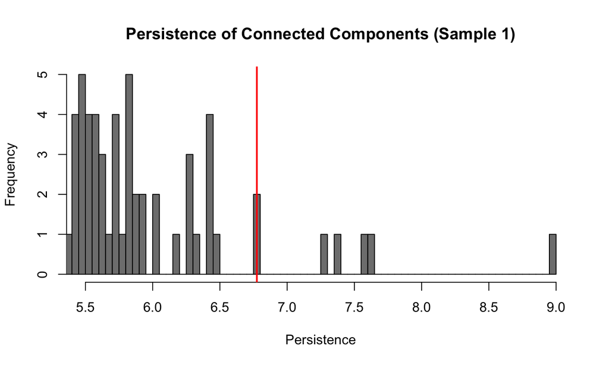

## Persistence

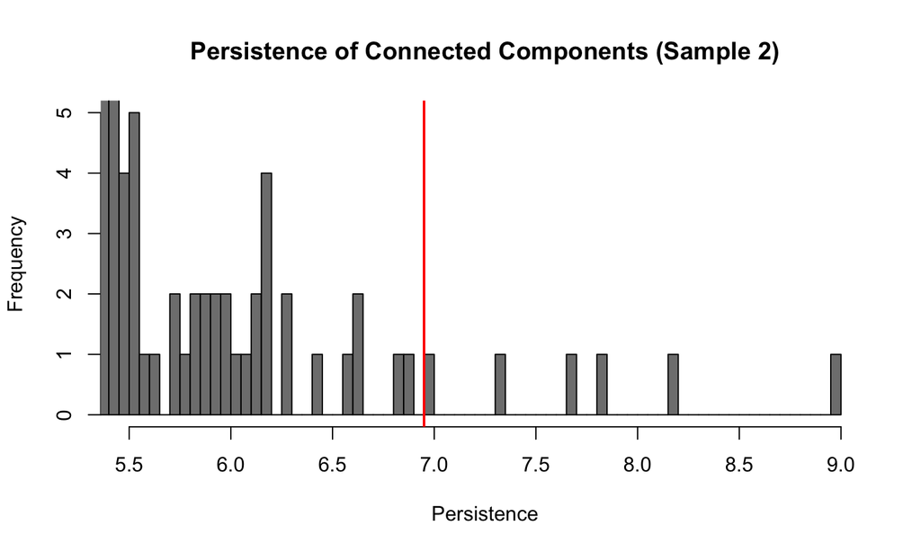

## Persistence

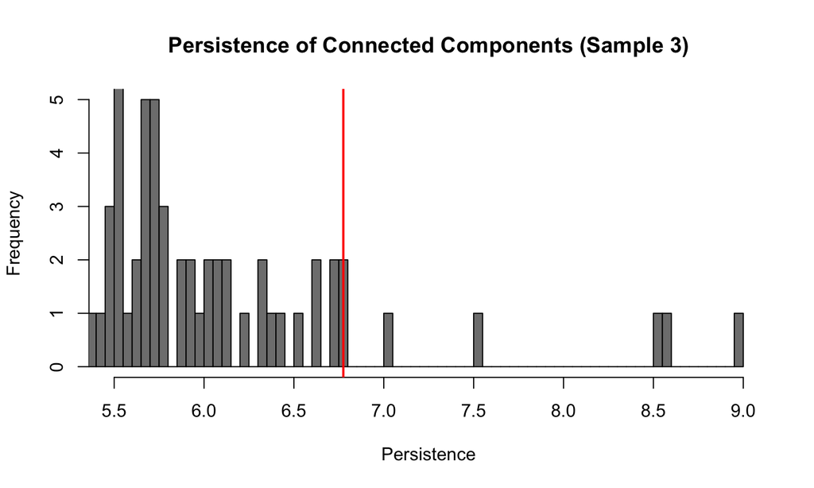

## Persistence

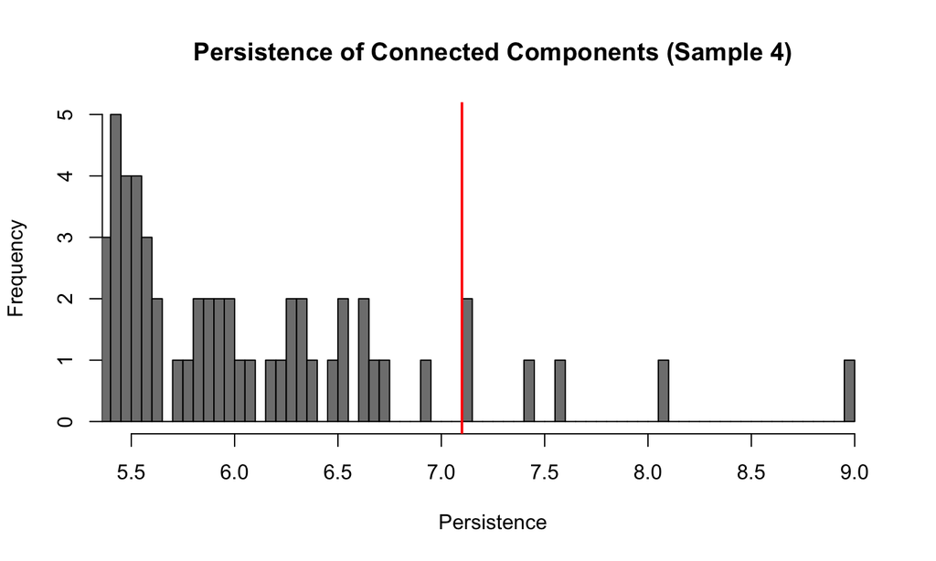

## Persistence

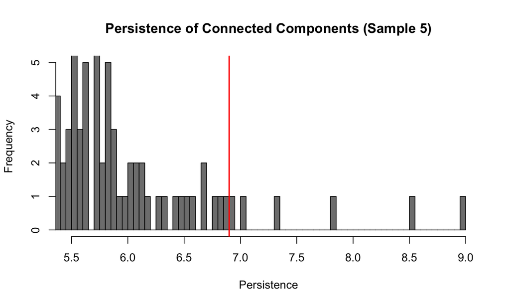

## TDA interpretation

- The 0-dimensional data from our persistent homology algorithm suggests 4-6 clusters in our data.
- 4 or so groups seem to be very distinct
- Agrees with the results of the original researchers' predictions using their support vector machine

## Other Techniques Hierarchical Clustering

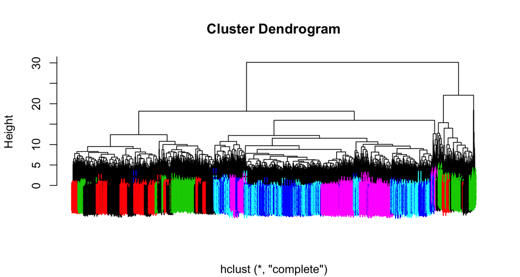

Suggests about 5 clusters, but when true labels are put on, the separation between certain activities is not very accurate.

## Other Techniques - Inspection of PCA

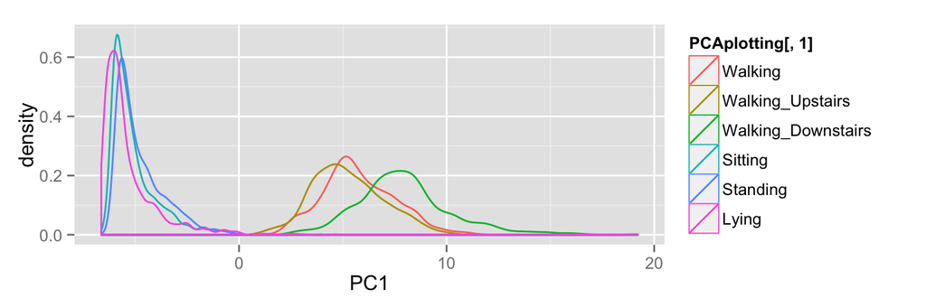

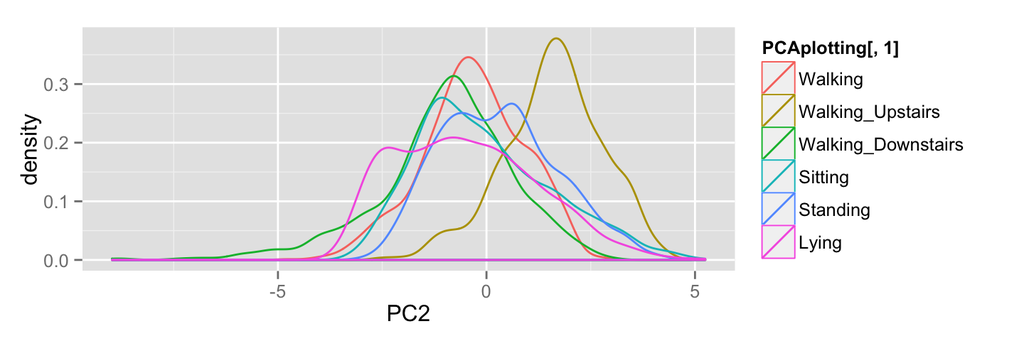

## Other Techniques - Inspection of PCA

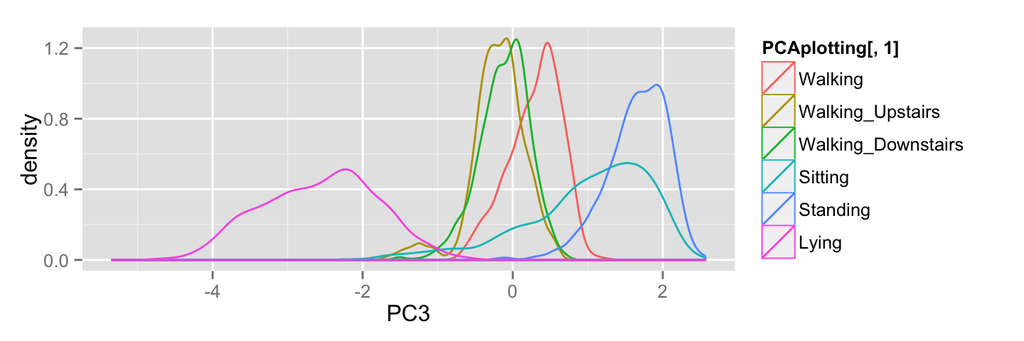

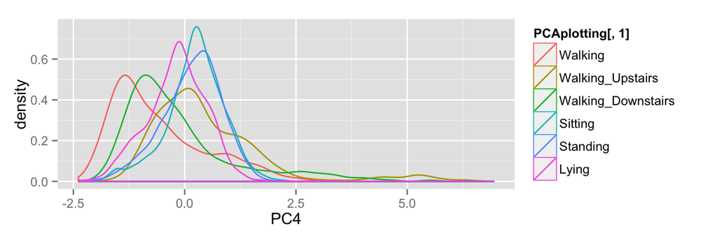

## Other Techniques - Inspection of PCA

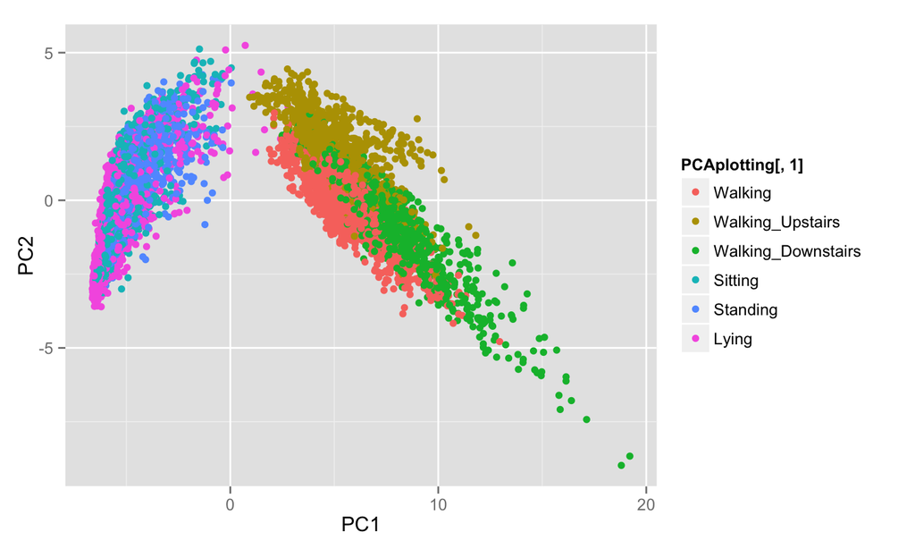

## Other Techniques - Inspection of PCA

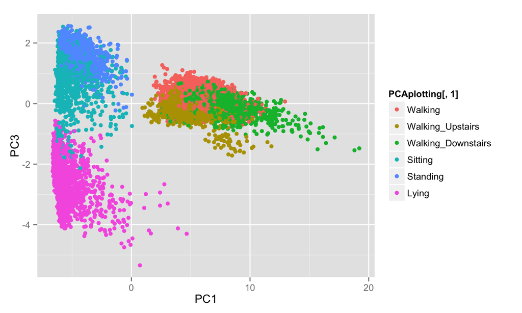

## Comparison

TDA does a better job at telling us the number of groups than PCA and performs that task at least as well as hierarchical clustering in this data set.

Unlike the other two methods, TDA is not practical to do on a data set of this size on a personal computer (other methods took less than a minute for the full data set).

## Classification

*Classification* is very similar to clustering, but has to deal with new data. It is the problem of identifying to which of a set of categories a new observation belongs (on the basis of some rules from some training set).

## Classification with TDA

I could find no conclusive literature on dealing with classification problems (with the new observations being single cases) through TDA, so I will propose the two I thought of.

### Naive Approach

The naive approach would be to classify a new observation in the same category as closest observation. Doing the algorithm, it would be the point which caused the connected component of the new observation to die. Note, that this is the same as the k-nearest neighbors (knn) approach with k equal to 1.

## Classification with TDA

### More Complex Approach

The second approach I thought of would be to take the component that caused the death of our single new observation, and assign the most common category from that entire connected component. Certain geometric structures and unequal sample sizes would limit the effectiveness of this approach in certain situations, but it would be more robust than knn with a k of 1. Any time there is a substantial probability of a new observation being further away from its category than that category is from a neighboring category, we would run into issues.

I cannot currently test this algorithm on this data set because it is not part of TDATools. It may be faster than `rca1pc` though, since it would not need to compute 1st dimensional homology.

## Prediction with knn

Since the second, more robust approach can't be empirically tested here, I will test the first approach, which is equivalent to knn with k of 1 on this data set.

True values along rows, predicted along columns:

```
##
## naive                  1   2   3   4   5   6
##   Walking            473  31  53   0   0   0
##   Walking_Upstairs     8 422  46   2   0   0
##   Walking_Downstairs  15  18 321   0   0   0
##   Sitting              0   0   0 389  81   3
##   Standing             0   0   0  99 451   1
##   Lying                0   0   0   1   0 533
```

Overall accuracy: 87.9%

## Conclusions

- TDA appears to be a very effective unsurpervised clustering technique.
- Performance was at least as useful as hierarchical clustering and much better than PCA
- Performance of naive surpervised classification was surprisingly effective compared to researchers' SVM
- Data sets with many observations in high dimensional space may not be practical
- R's usefullness in the actual persistent homology computations is extremely limited

## Ideas for Future Work

- Run the `rca1pc` function on the entire data set (may have enough time to do this before the paper is due)
- Develop a working program for the more complex classification method and test its effectiveness on synthetic and real data
- Use clustering and classification techniques on 1-dimensional persistence diagrams to try to improve separation between groups and improve accuracy
- Use clustering and classification on 1-dimensional persisence diagrams to try to identify different subjects

## References

- Data: Human Activity Recognition Using Smartphones Data Set. (2012). Retrieved October 6, 2014, from https://archive.ics.uci.edu/ml/datasets/Human+Activity+Recognition+Using+Smartphones
- Anguita, Davide, Alessandro Ghio, and Luca Oneto. 2012. “Human Activity Recognition on Smartphones Using a Multiclass Hardware-Friendly Support Vector Machine.” International Workshop of Ambient Assisted Living (IWAAL). http://link.springer.com/chapter/10.1007/978-3-642-35395-6_30.
- Fasy, Brittany T., Jisu Kim, Fabrizio Lecci, and Clément Maria. 2014. “Introduction to the R Package TDA.” http://cran.r-project.org/web/packages/TDA/vignettes/article.pdf.
- Tausz, Andrew. 2014. “pHom Reference Manual” http://cran.r-project.org/web/packages/phom/phom.pdf.